# Rhyme and cohort competitors in word recognition – a replication of Allopenna et al (1998)

This study is a replication of Allopenna et al (1998) using a 2AFC (instead of a 4AFC) paradigm. Thanks to Liz Simmons and Jim Magnuson for providing the visual and auditory stimuli.

The main research question is: In a web-based eye-tracking paradigm using webgazer.js, can we replicate standard onset competitor and rhyme competitor effects?

Answer: The analysis below suggests that onset competitor effects replicate very clearly and rhyme competitor effects do so less clearly. The relatively weaker rhyme competitor effects may be due to the relatively noisier web-based eye-tracking data – rhyme competitor effects are generally weaker than onset competitor effects and consequently more difficult to detect.

[Here](https://willclapp.github.io/145_cohort_rhyme/eyetracking_template-master/eyetrack_HRT.html)’s the experiment we’re analyzing.

**Participants:** 57 students from Judith Degen’s LING 145 “Introduction to Psycholinguistics” class, Autumn 2020, and their friends

**Materials:**

**Procedure:**

1. Subjects listened to instructions like “Find the bubbles” in a web-based 2AFC visual world paradigm.
2. Subjects clicked on the target object after each instruction to advance to the next trial.

**Results:**

Preprocessing

- Trials with wrong selections were removed. **4 cases**

Analysis

- computed regions of interest: target, competitor, center, other
- aligned time relative to target word onset and binned samples into **60**ms bins
- plotted proportions of looks over time (all regions vs just target and competitor)
- **additional analyses?**

```r
# load data
d = read.csv('../data/main2-cohort-merged.csv') %>%
  select(-proliferate.condition,-audio_loaded_time,-criticality,-error) %>%
  mutate(trial = tolower(trial),selected_img = tolower(selected_img), img_left = tolower(img_left), img_right = tolower(img_right)) %>%
  separate(trial,c("target_item","target_type")) %>%
  mutate(target_item=fct_recode(target_item, cookie = "cookies")) %>%
  separate(selected_img,c(NA,NA,"selected_item","selected_type",NA)) %>%
  separate(img_right,c(NA,NA,"right_item",NA,NA)) %>%
  separate(img_left,c(NA,NA,"left_item",NA,NA)) %>%
  mutate(target_location = case_when(left_item == target_item ~ "left",
                                     right_item == target_item ~ "right",
                                     TRUE ~ "no target/error")) %>%
  left_join(audio_info,by=c("target_item"))
```

[output not shown]

Compute accuracy and exclude trials with wrong selections. Also exclude JD test runs.

```
Ignoring unknown parameters: binwidth, bins, pad
```

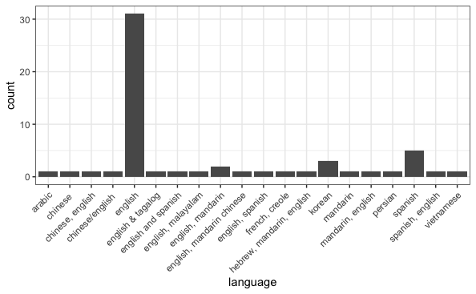

```r
# distribution of languages
ggplot(participants, aes(x=language)) +
  geom_histogram(stat="count") +
  theme(axis.text.x=element_text(angle=45, hjust=1,vjust=1))
```

Separate time and x/y coordinates into separate data points, one per row, and define regions of interest (ROIs).

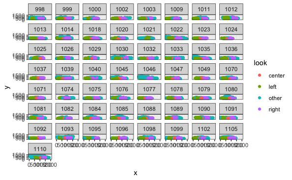

Bin samples and align time to the onset of the target word.

```r
# total number of samples:
nrow(first_samples)
```

```
[1] 1536
```

Plot proportions of looks to all regions (target, competitor, center, other)

```r
ggplot(toplot, aes(x=binned_time_rel_target_onset,y=proportion)) +
  geom_line(size=1, aes(color=region)) +
  geom_ribbon(aes(ymin=ymin,ymax=ymax,fill=region),alpha=.3) +
  scale_color_manual(values=cbPalette[2:5]) +
  scale_fill_manual(values=cbPalette[2:5]) +
  geom_vline(aes(xintercept=200),linetype="dashed",size=1) +
  geom_vline(data=durations,aes(xintercept=mean_audio_offset+200),linetype="dashed",size=1) +
  xlab("Time in ms relative to target word onset") +
  ylab("Proportion of looks") +
  geom_text(data=annotations,aes(label=Label)) +
  facet_wrap(~condition,nrow=3)
```

[figure not shown]

Plot proportions of looks to just target and competitor

```r
toplot = long_props %>%
  left_join(long_ymin,by=c("condition","binned_time_rel_target_onset","region")) %>%
  left_join(long_ymax,by=c("condition","binned_time_rel_target_onset","region"))  %>%
  mutate(region = fct_relevel(region, "target","competitor","center"))
```

```
Unknown levels in `f`: center
```

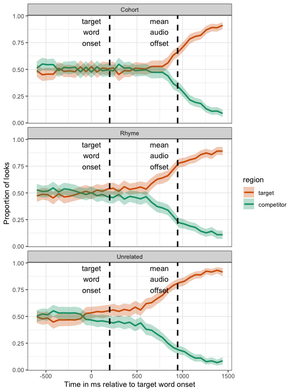

[figure not shown]

```r
ggplot(toplot, aes(x=binned_time_rel_target_onset,y=proportion)) +
  # geom_point() +
  geom_line(size=1, aes(color=region)) +
  geom_ribbon(aes(ymin=ymin,ymax=ymax,fill=region),alpha=.3) +
  scale_color_manual(values=cbPalette[2:5]) +
  scale_fill_manual(values=cbPalette[2:5]) +
  geom_vline(aes(xintercept=200),linetype="dashed",size=1) +
  geom_vline(data=durations,aes(xintercept=mean_audio_offset+200),linetype="dashed",size=1) +
  xlab("Time in ms relative to target word onset") +
  ylab("Proportion of looks") +
  geom_text(data=annotations,aes(label=Label)) +
  facet_grid(native_language~condition)
```

[output not shown]

```r
ggplot(toplot, aes(x=binned_time_rel_target_onset,y=proportion)) +
  # geom_point() +
  geom_line(size=1, aes(color=condition)) +
  geom_ribbon(aes(ymin=ymin,ymax=ymax,fill=condition),alpha=.3) +
  scale_color_manual(values=cbPalette[2:5]) +
  scale_fill_manual(values=cbPalette[2:5]) +
  geom_vline(aes(xintercept=200),linetype="dashed",size=1) +
  geom_vline(data=durations,aes(xintercept=mean_audio_offset+200),linetype="dashed",size=1) +
  xlab("Time in ms relative to target word onset") +
  ylab("Proportion of looks") +
  geom_text(data=annotations,aes(label=Label)) +
  facet_grid(native_language~region)
```

[output not shown]